# Festive Midlands Analyst Network Huddle

Christmas 2020

❅

❅

❆

❄

❅

❆

❄

❅

❆

❄

## Ice breaker

Why can’t you tell a joke while ice skating?

[figure not shown]

## Because the ice will crack up.

[figure not shown]

## Seriously…

### This is what we are going to do…

1. Think of a word that would follow Christmas
2. When I say the word you’ve chosen, unmute and say hello!

[figure not shown]

## What did I miss out?…

## 4 unusual things to do on Christmas Day…

## At number 4

In 2017, there were 7902 people browsing the ONS website that day. [Quote](https://blog.ons.gov.uk/2018/12/07/the-twelve-stats-of-christmas/): “proving that, for some people at least, Christmas really is all about stats.”

[figure not shown]

## At number 3

The same year, according to HMRC, 2590 people decided to file their online tax returns on Christmas Day.

[figure not shown]

## At number 2

On Christmas Day in 2016, ONS data show that 1391 babies were born in England & Wales.

[figure not shown]

## At number 1

Over the twenty years from 1996-2015, there have been 102 marriages on Christmas Day, an average of just 5 a year.

[figure not shown]

## Do you have any unusual Christmas traditions?…

## Seasonal question time…

What is the likelihood of having a Christmas birthday?

- Highly likely
- Same as any other day
- Not likely

## ONS have answered this!

[How popular is your birthday?](https://www.ons.gov.uk/peoplepopulationandcommunity/birthsdeathsandmarriages/livebirths/articles/howpopularisyourbirthday/2015-12-18)

“While the Christmas holidays may be a popular time to make a baby there tend to be fewer babies born, with 6 of the 10 least popular dates of birth falling in the Christmas and New Year period.”

## This needs a chart…

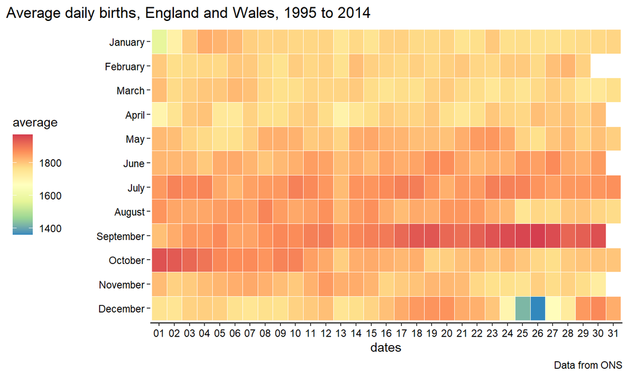

## Time for another joke…

## Disclaimer: this is highly unlikely to cause much mirth

What do you call a snowman in summer?

[figure not shown]

## A puddle…

## A visual representation

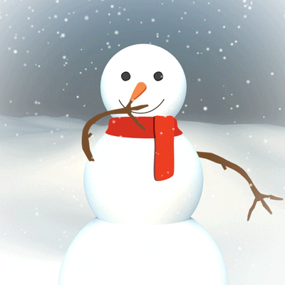

## Predicting a White Christmas

How many days does the Met Office say it can predict a White Christmas in advance?

- 1 day
- 3 days
- 5 days
- 7 days

## Check the weather forecast

[5 days before](https://www.metoffice.gov.uk/weather/learn-about/weather/types-of-weather/snow/white-christmas)

[figure not shown]

## Joke

Why is it getting harder to buy Advent calendars?

[figure not shown]

## Because their days are numbered

[figure not shown]

## And they are according to ONS

“One victim of technology is the personal diary – once a popular stocking filler. British manufacturers sold £41 million of diaries in 2008 but only £17 million in 2017.” Source: [ONS](https://blog.ons.gov.uk/2018/12/07/the-twelve-stats-of-christmas/)

[figure not shown]

## Happy Christmas

[figure not shown]